# Topic 2: Predicting the number of Twitter followers

### 9.3 XGBoost Score Summary

We then examine the output of the optimisation process to obtain the optimised values for the 6 parameters for tuning. In this case, most optimised set of parameters corresponds with the 9th iteration which returns the lowest Score (Score = min(xgbcv$evaluation_log$test_rmse_mean)).

1. eta (learning rate): 1
2. gamma : 0
3. max_depth : 6
4. min_child_weight : 25,
5. subsample : 1
6. nfold : 3

It is worthy to note that getBestPars function did not return the parameters that corresponds to the lowest MSE Score. This is even so after we amended FUN Scoring function to OLS regression Score function with maximise set as FALSE. We have tried using the getBestPars output set of parameters to do out of sample prediction and it did not perform as well as the set of parameters outline in 1- 6 above.

Hence, we will manually input the 1-6 parameters above as the optimised parameter for training the XGBoost models. The trained models will then create predictions with the lowest RMSE within the boundaries we have set for our parameters

```r
#examine the output summary
#again, have to use capital letters required by the package
opt_obj$scoreSummary
```

```
    Epoch Iteration    eta  gamma max_depth min_child_weight subsample nfold
 1:     0         1 0.3877   5.83         3           23.637    0.6108     9
 2:     0         2 0.2212  33.77         9           18.424    0.9222     6
 3:     0         3 0.1353  28.44         9            6.793    0.4921     8
 4:     0         4 0.7217  49.76         6           17.584    0.3109     3
 5:     0         5 0.9144  89.25         5           12.051    0.3588     5
 6:     0         6 0.7045  58.30         3            3.197    0.8748     6
 7:     0         7 0.4494  77.72         7           10.302    0.7575     7
 8:     1         8 1.0000 100.00         6           25.000    0.7385     3
 9:     2         9 1.0000   0.00         6           25.000    1.0000     3
10:     3        10 0.6255 100.00        10           25.000    1.0000     3
11:     4        11 0.2083  65.57         2           25.000    0.2500     3
12:     5        12 0.0000 100.00        10           25.000    1.0000    10
    gpUtility acqOptimum inBounds Elapsed    Score nrounds errorMessage
 1:        NA      FALSE     TRUE    2.10 0.001630      24           NA
 2:        NA      FALSE     TRUE    6.92 0.001646      55           NA
 3:        NA      FALSE     TRUE   13.19 0.001630      91           NA
 4:        NA      FALSE     TRUE    0.56 0.001651      13           NA
 5:        NA      FALSE     TRUE    1.08 0.001647      13           NA
 6:        NA      FALSE     TRUE    1.00 0.001637      14           NA
 7:        NA      FALSE     TRUE    5.69 0.001656      41           NA
 8:    0.5754       TRUE     TRUE    1.07 0.001666      19           NA
 9:    0.4466       TRUE     TRUE    0.48 0.001545       6           NA
10:    0.5009       TRUE     TRUE    1.50 0.001659      17           NA
11:    0.4710       TRUE     TRUE    0.62 0.001647      52           NA
12:    0.3822       TRUE     TRUE    0.42 0.499400       1           NA
```

```r
#obtain the optimised values for the 6 parameters we want to tune
#the built-in function output the FUN input arguments only.
getBestPars(opt_obj)
```

```
$eta
[1] 0

$gamma
[1] 100

$max_depth
[1] 10

$min_child_weight
[1] 25

$subsample
[1] 1

$nfold
[1] 10
```

```r
#take the optimized values for the six parameters and train the XGBoost model
#take the optimal parameters for xgboost()
params <- list(eta = 1,
               gamma = 0,
               max_depth = 6,
               min_child_weight = 25,
               subsample = 1,
               nfold = 3,
               objective = "reg:squarederror")

#the numrounds which gives the min RMSE score
numrounds <- opt_obj$scoreSummary$nrounds[
  which(opt_obj$scoreSummary$Score
        == min(opt_obj$scoreSummary$Score))]

fit_tuned26 <- xgboost(params = params,
                     data = x21,
                     label = y21,
                     nrounds = numrounds,
                     eval_metric = "rmse")
fit_tuned27 <- xgboost(params = params,
                     data = x22,
                     label = y22,
                     nrounds = numrounds,
                     eval_metric = "rmse")
fit_tuned28 <- xgboost(params = params,
                     data = x23,
                     label = y23,
                     nrounds = numrounds,
                     eval_metric = "rmse")
fit_tuned29 <- xgboost(params = params,
                     data = x24,
                     label = y24,
                     nrounds = numrounds,
                     eval_metric = "rmse")
fit_tuned30 <- xgboost(params = params,
                     data = x25,
                     label = y25,
                     nrounds = numrounds,
                     eval_metric = "rmse")
```

### 9.4 In Sample Accuracy

We run the optimised parameters obtained from Bayesian Optimisation technique to train 5 models (see section 8.1 for models selected) using XGBoost. The predicted growth rate from Train data is then used to compute the actual no of Twitter followers in the respective dates.

Based on the RMSE results computed, XG28 (Non financial model on XGBoost) performs the best in terms of in sample prediction with an in sample RMSE of 640.5. On the other hand, the model that performs the worse for in sample prediction is XG27 (Financial(lag), StockPrice(lag) model on XGBoost).

```r
# compute in sample predicted growth rate
Train$XG_rate_26 <- predict(fit_tuned26, x21)
Train$XG_rate_27 <- predict(fit_tuned27, x22)
Train$XG_rate_28 <- predict(fit_tuned28, x23)
Train$XG_rate_29 <- predict(fit_tuned29, x24)
Train$XG_rate_30 <- predict(fit_tuned30, x25)

# using in sample predicted growth rate, compute in sample predicted followers.
Train$Followers_XG_26<- (1+Train$XG_rate_26)*Train$followers_lag
Train$Followers_XG_27<- (1+Train$XG_rate_27)*Train$followers_lag
Train$Followers_XG_28<- (1+Train$XG_rate_28)*Train$followers_lag
Train$Followers_XG_29<- (1+Train$XG_rate_29)*Train$followers_lag
Train$Followers_XG_30<- (1+Train$XG_rate_30)*Train$followers_lag

# compute rmse to evaluate in sample prediction accuracy
rmse <- function(v1, v2) {
  sqrt(mean((v1 - v2)^2, na.rm = T))
}

RMSE <- c(rmse(Train$followers,Train$Followers_XG_26),
          rmse(Train$followers,Train$Followers_XG_27),
          rmse(Train$followers,Train$Followers_XG_28),
          rmse(Train$followers,Train$Followers_XG_29),
          rmse(Train$followers,Train$Followers_XG_30))

## To get the RMSE for all the models
names(RMSE) <- c("XG26", "XG27", "XG28", "XG29", "XG30")
RMSE
```

```
 XG26  XG27  XG28  XG29  XG30
694.7 707.9 640.5 677.0 706.4
```

### 9.5 Prediction of Test Followers

```r
#evaluation of the tuned model
#prediction on test sample

#merge the last day of followers in Train data to Test data
Test26 <- full_join(last_day_followers, Test, by = join_by(gvkey, date))
Test26 <- Test26 %>% arrange(gvkey, date) %>%
  select(-sic.x) %>%
  rename(`sic` = sic.y) %>%
  select(-ID.x) %>%
  rename(`ID` = ID.y)

Test27 <- full_join(last_day_followers, Test, by = join_by(gvkey, date))
Test27 <- Test27 %>% arrange(gvkey, date) %>%
  select(-sic.x) %>%
  rename(`sic` = sic.y) %>%
  select(-ID.x) %>%
  rename(`ID` = ID.y)

Test28 <- full_join(last_day_followers, Test, by = join_by(gvkey, date))
Test28 <- Test28 %>% arrange(gvkey, date) %>%
  select(-sic.x) %>%
  rename(`sic` = sic.y) %>%
  select(-ID.x) %>%
  rename(`ID` = ID.y)

Test29 <- full_join(last_day_followers, Test, by = join_by(gvkey, date))
Test29 <- Test29 %>% arrange(gvkey, date) %>%
  select(-sic.x) %>%
  rename(`sic` = sic.y) %>%
  select(-ID.x) %>%
  rename(`ID` = ID.y)

Test30 <- full_join(last_day_followers, Test, by = join_by(gvkey, date))
Test30 <- Test30 %>% arrange(gvkey, date) %>%
  select(-sic.x) %>%
  rename(`sic` = sic.y) %>%
  select(-ID.x) %>%
  rename(`ID` = ID.y)

pred.xgb.tuned26 <- predict(fit_tuned26, xvals21)
pred.xgb.tuned27 <- predict(fit_tuned27, xvals22)
pred.xgb.tuned28 <- predict(fit_tuned28, xvals23)
pred.xgb.tuned29 <- predict(fit_tuned29, xvals24)
pred.xgb.tuned30 <- predict(fit_tuned30, xvals25)
print(pred.xgb.tuned27)
```

[output not shown]

[output cut: 1000 more lines]

```r
suppressWarnings({
while (any(is.na(Test26$followers))) {
  Test26 <- Test26 %>%
    mutate(followers= ifelse(is.na(followers), lag(followers) * (1+pred.xgb.tuned26), followers))
}
while (any(is.na(Test27$followers))) {
  Test27 <- Test27 %>%
    mutate(followers= ifelse(is.na(followers), lag(followers) * (1+pred.xgb.tuned27), followers))
}
while (any(is.na(Test28$followers))) {
  Test28 <- Test28 %>%
    mutate(followers= ifelse(is.na(followers), lag(followers) * (1+pred.xgb.tuned28), followers))
}
while (any(is.na(Test29$followers))) {
  Test29 <- Test29 %>%
    mutate(followers= ifelse(is.na(followers), lag(followers) * (1+pred.xgb.tuned29), followers))
}
while (any(is.na(Test30$followers))) {
  Test30 <- Test30 %>%
    mutate(followers= ifelse(is.na(followers), lag(followers) * (1+pred.xgb.tuned30), followers))
}
})
```

```r
pacman::p_load(tidyverse)
# merge the six companies with other companies
Test_submission26 <- Test26 %>% select(gvkey, date, followers, ID)
Test_submission26 <- rbind(Test_submission26, Test_6)
Test_submission26 <- Test_submission26 %>% filter(date>=20170701)
Test_submission26$followers <- round(Test_submission26$followers)
Followers_submisson_M26 <- Test_submission26 %>% select(ID, followers)

Test_submission27 <- Test27 %>% select(gvkey, date, followers, ID)
Test_submission27 <- rbind(Test_submission27, Test_6)
Test_submission27 <- Test_submission27 %>% filter(date>=20170701)
Test_submission27$followers <- round(Test_submission27$followers)
Followers_submisson_M27 <- Test_submission27 %>% select(ID, followers)

Test_submission28 <- Test28 %>% select(gvkey, date, followers, ID)
Test_submission28 <- rbind(Test_submission28, Test_6)
Test_submission28 <- Test_submission28 %>% filter(date>=20170701)
Test_submission28$followers <- round(Test_submission28$followers)
Followers_submisson_M28 <- Test_submission28 %>% select(ID, followers)

Test_submission29 <- Test29 %>% select(gvkey, date, followers, ID)
Test_submission29 <- rbind(Test_submission29, Test_6)
Test_submission29 <- Test_submission29 %>% filter(date>=20170701)
Test_submission29$followers <- round(Test_submission29$followers)
Followers_submisson_M29 <- Test_submission29 %>% select(ID, followers)

Test_submission30 <- Test30 %>% select(gvkey, date, followers, ID)
Test_submission30 <- rbind(Test_submission30, Test_6)
Test_submission30 <- Test_submission30 %>% filter(date>=20170701)
Test_submission30$followers <- round(Test_submission30$followers)
Followers_submisson_M30 <- Test_submission30 %>% select(ID, followers)

# save the sample of submission
write.csv(Followers_submisson_M26, "submission_XGM26.csv", row.names = FALSE)
write.csv(Followers_submisson_M27, "submission_XGM27.csv", row.names = FALSE)
write.csv(Followers_submisson_M28, "submission_XGM28.csv", row.names = FALSE)
write.csv(Followers_submisson_M29, "submission_XGM29.csv", row.names = FALSE)
write.csv(Followers_submisson_M30, "submission_XGM30.csv", row.names = FALSE)
```

### 9.6 Out of Sample Evaluation

It is worthy to note that XGBoost models outperform our domain knowledge models in terms of out of sample prediction.

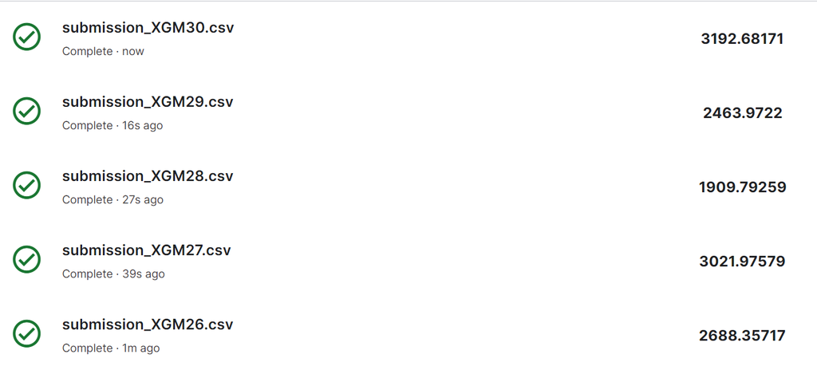

## 10. Random Forest

### 10.1 Hyperparameter Tuning

Random Forest is a powerful ensemble learning technique widely used for regression and classification tasks. The technique involves the building of decision trees on bootstrap dataset and running predictions on each tree before aggregating (or bagging) the results. This mitigate the overfitting issues faced by decision trees, thus reducing variance.

Hyperparameter tuning is crucial for optimizing the performance of Random Forest models. various combinations of hyperparameters are tested to find the optimal configuration that yields the best model performance.

We performed hyperparameter tuning for Random Forest using the tuneRF function from the randomForest package in R. Below is the brief explanation of the steps performed:

1. set.seed(2021) for reproducibility of results.
2. randomForest::tuneRF : Executes grid search with cross-validation using the tuneRF function, which  
   automatically selects the optimal values for hyperparameters based on out-of-bag (OOB) error estimates.
3. Extract Optimal mtry Value: Identifies the optimal value for the mtry hyperparameter, which represents the number of variables randomly sampled as candidates at each split.
4. Run Random Forest Models with Optimal mtry: Train Random Forest models (rf_model31, rf_model32, …, rf_model35) using the optimal mtry value obtained from the tuning process for different formulas (ML_Mod21_formula, ML_Mod22_formula, …, ML_Mod25_formula). kindly refer to section 8.1 for the 5 models selected for running on advanced ML algorthims

```r
#---------Random Forest Hyperparameter Tuning and Ensembling Method ---------------------#
set.seed(2021)
#define hyperparameter grid for tuning
hyperparameters <- list(
  n_estimators = c(50, 100, 150),      #no of trees in the forest
  max_depth = c(5, 10, 15),            #max depth of trees
  min_samples_split = c(2, 5, 10),     #min samples required to split a node
  min_samples_leaf = c(1, 2, 4),       #min samples required at each leaf node
  max_features = c("sqrt", "log2"),    #no of features to consider at each split
  bootstrap = c(TRUE, FALSE)           #whether to use bootstrap samples
)

#identify categorical variables
categorical_vars <- sapply(Train, is.factor)
print (categorical_vars)
```

```
                 date                 gvkey                   atq
                FALSE                 FALSE                 FALSE
       p_daily_change              volatile    p_daily_change_lag
                FALSE                 FALSE                 FALSE
         volatile_lag                    bm                pe_exi
                FALSE                 FALSE                 FALSE
                   ps                   pcf                   dpr
                FALSE                 FALSE                 FALSE
                  npm                 opmbd                 opmad
                FALSE                 FALSE                 FALSE
                  gpm                   roa                   roe
                FALSE                 FALSE                 FALSE
                 roce               debt_at              de_ratio
                FALSE                 FALSE                 FALSE
               intcov            cash_ratio           quick_ratio
                FALSE                 FALSE                 FALSE
           curr_ratio              inv_turn               at_turn
                FALSE                 FALSE                 FALSE
          debt_assets                   ptb             rect_turn
                FALSE                 FALSE                 FALSE
             sale_nwc              divyield                bm_lag
                FALSE                 FALSE                 FALSE
           pe_exi_lag                ps_lag               pcf_lag
                FALSE                 FALSE                 FALSE
              dpr_lag               npm_lag             opmbd_lag
                FALSE                 FALSE                 FALSE
            opmad_lag               gpm_lag               roa_lag
                FALSE                 FALSE                 FALSE
              roe_lag              roce_lag           debt_at_lag
                FALSE                 FALSE                 FALSE
         de_ratio_lag            intcov_lag        cash_ratio_lag
                FALSE                 FALSE                 FALSE
      quick_ratio_lag        curr_ratio_lag          inv_turn_lag
                FALSE                 FALSE                 FALSE
          at_turn_lag       debt_assets_lag               ptb_lag
                FALSE                 FALSE                 FALSE
        rect_turn_lag          sale_nwc_lag          divyield_lag
                FALSE                 FALSE                 FALSE
           is_annouce           red_annouce        no_annoucement
                FALSE                 FALSE                 FALSE
```

[output cut: 53 more lines]

```
                FALSE                 FALSE                 FALSE
      Follower_LA_M22       Follower_LA_M23       Follower_LA_M24
                FALSE                 FALSE                 FALSE
      Follower_LA_M25      Follower_LA_SE21      Follower_LA_SE22
                FALSE                 FALSE                 FALSE
     Follower_LA_SE23      Follower_LA_SE24      Follower_LA_SE25
                FALSE                 FALSE                 FALSE
           XG_rate_26            XG_rate_27            XG_rate_28
                FALSE                 FALSE                 FALSE
           XG_rate_29            XG_rate_30       Followers_XG_26
                FALSE                 FALSE                 FALSE
      Followers_XG_27       Followers_XG_28       Followers_XG_29
                FALSE                 FALSE                 FALSE
      Followers_XG_30
                FALSE
```

```
mtry = 2  OOB error = 0.000002003
Searching left ...
Searching right ...
mtry = 3    OOB error = 0.000002001
0.0008748 0.05
```

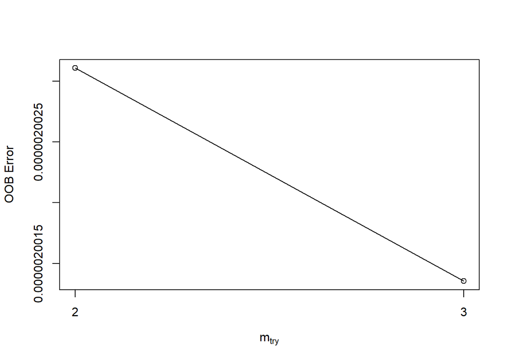

```r
#exclude categorical variables from the dataset
#randomforest cannot handle categorical predictors with >53 categories
Train_numeric <- Train[, !categorical_vars]

#perform grid search with cross-validation
rf_grid <- randomForest::tuneRF(x = Train_numeric[, -which(names(Train_numeric) == "growth_rate")],
                                y = Train_numeric$growth_rate,
                                mtryStart = 2,
                                ntreeTry = 100,
                                stepFactor = 1.5,
                                improve = 0.05,
                                trace = TRUE,
                                plot = TRUE)
```

```r
#extract the optimal mtry value
optimal_mtry <- rf_grid[which.min(rf_grid)]

#finally, rerun the randomForest() function with the updated mtry parameter
rf_model31 <- randomForest(ML_Mod21_formula,
                         data = Train,
                         mtry = optimal_mtry)
rf_model32 <- randomForest(ML_Mod22_formula,
                         data = Train,
                         mtry = optimal_mtry)
rf_model33 <- randomForest(ML_Mod23_formula,
                         data = Train,
                         mtry = optimal_mtry)
rf_model34 <- randomForest(ML_Mod24_formula,
                         data = Train,
                         mtry = optimal_mtry)
rf_model35 <- randomForest(ML_Mod25_formula,
                         data = Train,
                         mtry = optimal_mtry)
```

### 10.2 In Sample Evaluation

Next, we use the trained Random forest model to make prediction on Twitter follower growth rate on Train data. The Twitter follower growth rate is then use to derive the predicted daily Twitter followers count.

```r
#make predictions on growth_rate on Train data
Train$RTpred_rate31 <- predict(rf_model31, Train)
Train$RTpred_rate32 <- predict(rf_model32, Train)
Train$RTpred_rate33 <- predict(rf_model33, Train)
Train$RTpred_rate34 <- predict(rf_model34, Train)
Train$RTpred_rate35 <- predict(rf_model35, Train)

#create rmse function to measure in sample accuracy
rmse <- function(v1, v2) {
  sqrt(mean((v1 - v2)^2, na.rm = T))
}

#compute predicted followers using predicted growth rate obtained from random Tree forest
Train$RTfollowers31 <- (1+Train$RTpred_rate31)*Train$followers_lag
Train$RTfollowers32 <- (1+Train$RTpred_rate32)*Train$followers_lag
Train$RTfollowers33 <- (1+Train$RTpred_rate33)*Train$followers_lag
Train$RTfollowers34 <- (1+Train$RTpred_rate34)*Train$followers_lag
Train$RTfollowers35 <- (1+Train$RTpred_rate35)*Train$followers_lag

#evaluate the in sample performance (rmse) of the model
RMSE <- c(rmse(Train$followers,Train$RTfollowers31),
          rmse(Train$followers,Train$RTfollowers32),
          rmse(Train$followers,Train$RTfollowers33),
          rmse(Train$followers,Train$RTfollowers34),
          rmse(Train$followers,Train$RTfollowers35))

## To get the RMSE for all the models
names(RMSE) <- c("RF31", "RF32", "RF33", "RF34", "RF35")
RMSE
```

```
 RF31  RF32  RF33  RF34  RF35
749.1 786.6 921.8 779.4 814.7
```

### 10.3 Prediction of Test Followers

To ensure that our Random Forest Model is accurate in prediction, we went on to run our Random Forest model on Test data to make out of sample prediction. Based on the out of sample prediction, RF Model 31 (Financial Model) performs the best followed by RF Model 34 (Combined Model).

Random Forest succeeded in enhancing our domain knowledge model prediction capabilities. Random Forest ensembling techniques on random sampling and creation of random subsets of features and aggregation of each parallel trees is effective in increasing the prediction capabilities of model on smaller dataset. However, the boostraping and bagging techniques in Random Forest is not as powerful as the boosting techniques used in XGBoost on enhancing prediction accuracy of our model.

```r
#----------------- out of sample prediction----------------------------------------#
library(dplyr)

#make predictions on growth_rate on Test data
Test31 <- Test
Test31$RTpred_rate31 <- predict(rf_model31, Test31)
Test32 <- Test
Test32$RTpred_rate32 <- predict(rf_model32, Test32)
Test33 <- Test
Test33$RTpred_rate33 <- predict(rf_model33, Test33)
Test34 <- Test
Test34$RTpred_rate34 <- predict(rf_model34, Test34)
Test35 <- Test
Test35$RTpred_rate35 <- predict(rf_model35, Test35)


#merge the last day of followers in Train data to Test data
Test31 <- full_join(last_day_followers, Test31, by = join_by(gvkey, date))
Test31 <- Test31 %>% arrange(gvkey, date) %>%
  select(-sic.x) %>%
  rename(`sic` = sic.y) %>%
  select(-ID.x) %>%
  rename(`ID` = ID.y)

Test32 <- full_join(last_day_followers, Test32, by = join_by(gvkey, date))
Test32 <- Test32 %>% arrange(gvkey, date) %>%
  select(-sic.x) %>%
  rename(`sic` = sic.y) %>%
  select(-ID.x) %>%
  rename(`ID` = ID.y)

Test33 <- full_join(last_day_followers, Test33, by = join_by(gvkey, date))
Test33 <- Test33 %>% arrange(gvkey, date) %>%
  select(-sic.x) %>%
  rename(`sic` = sic.y) %>%
  select(-ID.x) %>%
  rename(`ID` = ID.y)

Test34 <- full_join(last_day_followers, Test34, by = join_by(gvkey, date))
Test34 <- Test34 %>% arrange(gvkey, date) %>%
  select(-sic.x) %>%
  rename(`sic` = sic.y) %>%
  select(-ID.x) %>%
  rename(`ID` = ID.y)

Test35 <- full_join(last_day_followers, Test35, by = join_by(gvkey, date))
Test35 <- Test35 %>% arrange(gvkey, date) %>%
  select(-sic.x) %>%
  rename(`sic` = sic.y) %>%
  select(-ID.x) %>%
  rename(`ID` = ID.y)

while (any(is.na(Test31$followers))) {
  Test31 <- Test31 %>%
    mutate(followers = ifelse(is.na(followers), lag(followers) * (1+Test31$RTpred_rate31 ), followers))
}
while (any(is.na(Test32$followers))) {
  Test32 <- Test32 %>%
    mutate(followers = ifelse(is.na(followers), lag(followers) * (1+Test32$RTpred_rate32 ), followers))
}
while (any(is.na(Test33$followers))) {
  Test33 <- Test33 %>%
    mutate(followers = ifelse(is.na(followers), lag(followers) * (1+Test33$RTpred_rate33 ), followers))
}
while (any(is.na(Test34$followers))) {
  Test34 <- Test34 %>%
    mutate(followers = ifelse(is.na(followers), lag(followers) * (1+Test34$RTpred_rate34 ), followers))
}
while (any(is.na(Test35$followers))) {
  Test35 <- Test35 %>%
    mutate(followers = ifelse(is.na(followers), lag(followers) * (1+Test35$RTpred_rate35 ), followers))
}

#-----------------------generate Kaggle submission file------------------------------#

# merge the six companies with other companies 6492
Test31 <- Test31 %>% select(gvkey, date, followers, ID)
Test31 <- rbind(Test31, Test_6)
Test31 <- Test31 %>% filter(date>=20170701)
Test31$followers <- round(Test31$followers)
Followers_submisson_RF31 <- Test31 %>% select(ID, followers)

Test32 <- Test32 %>% select(gvkey, date, followers, ID)
Test32 <- rbind(Test32, Test_6)
Test32<- Test32 %>% filter(date>=20170701)
Test32$followers <- round(Test32$followers)
Followers_submisson_RF32 <- Test32 %>% select(ID, followers)

Test33 <- Test33 %>% select(gvkey, date, followers, ID)
Test33 <- rbind(Test33, Test_6)
Test33 <- Test33 %>% filter(date>=20170701)
Test33$followers <- round(Test33$followers)
Followers_submisson_RF33 <- Test33 %>% select(ID, followers)

Test34 <- Test34 %>% select(gvkey, date, followers, ID)
Test34 <- rbind(Test34, Test_6)
Test34 <- Test34 %>% filter(date>=20170701)
Test34$followers <- round(Test34$followers)
Followers_submisson_RF34 <- Test34 %>% select(ID, followers)

Test35 <- Test35 %>% select(gvkey, date, followers, ID)
Test35 <- rbind(Test35, Test_6)
Test35 <- Test35 %>% filter(date>=20170701)
Test35$followers <- round(Test35$followers)
Followers_submisson_RF35 <- Test35 %>% select(ID, followers)

# save the sample of submission
write.csv(Followers_submisson_RF31, "submission_RF31.csv", row.names = FALSE)
write.csv(Followers_submisson_RF32, "submission_RF32.csv", row.names = FALSE)
write.csv(Followers_submisson_RF33, "submission_RF33.csv", row.names = FALSE)
write.csv(Followers_submisson_RF34, "submission_RF34.csv", row.names = FALSE)
write.csv(Followers_submisson_RF35, "submission_RF35.csv", row.names = FALSE)
```

### 10.4 Out of Sample Evaluation

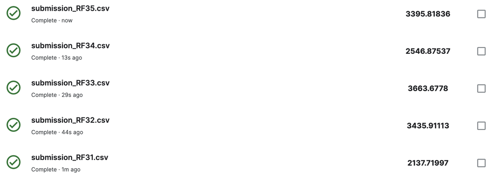

## 11. Ensemble

After using LASSO, XGboost and Random Forest ensembling techniques, we proceed to use simple Ensemble methods (Ensemble by average and Ensemble by weighted average) to further improve our predictionn.. We choose financial model 3 and non-financial model 1 to try to obtain a better prediction result.

We average the financial model 3 and non-financial model 1 test prediction as the predicted growth rate. The result shows that the RMSE of average predictions in train data is 918.2, which means the bias is not lowered too much. However, the Kaggle result shows that the Ensemble by average significantly improves the model and its rank is higher than non-financial model 3.

The following is to give two models different weights to check how different weights will impact the predictions. Because the best non-financial model which is non-financial model 3 performs better than financial model 3, we make a hypothesis that giving more weights to non-financial model will get better result. We take 0.25 as a step to test the result, it turns out that a higher weights on non-financial model than on financial indeed will get a higher score and 0.25 weights on financial model and 0.75 non-financial model ranks the highest among all the weights.

Next, we allocate more elaborate weights to each model from 0.1 to 0.9 by 0.1 to verify hypothesis. The best performance shows when financial model is given 0.4 weights and non-financial model is given 0.6 weights, and it exceeds 0.25 weight result.

```r
#-----------create Financial Model 3 and Non Financial Model1 formula--------------#

Fin_Mod <- lm(growth_rate ~ bm + pe_exi + ps + pcf + dpr + npm + opmbd + opmad + gpm + roa + roe + roce + debt_at + de_ratio + intcov + cash_ratio + quick_ratio + curr_ratio + inv_turn + at_turn + debt_assets + ptb + rect_turn + sale_nwc + divyield + p_daily_change + volatile + pop_ind + is_mon + is_tue + is_wed + is_thu + is_fri + is_sat + log(atq)+factor(sic),data=Train)

Non_Fin_Mod <- lm(growth_rate ~ is_annouce + red_annouce + no_annoucement + TFF + coleman_liau + flesch + fog_info + num_words + bio_complete + has_url + hashtags_count + has_hashtags + contains_company_name + contains_words + custom_content + days_joined + pop_ind + is_mon + is_tue + is_wed + is_thu + is_fri + is_sat + log(atq),data=Train)

## Predict in Train data
Train$pre_finaicl_mod3 <- predict(Fin_Mod, Train)
Train$pre_non_fin_mod1 <- predict(Non_Fin_Mod,Train)

## Get Average predicted growth rate
Train$avr_pre <- (Train$pre_finaicl_mod3+Train$pre_non_fin_mod1)/2
Train$wt_pre_0.25 <- (Train$pre_finaicl_mod3*0.25+Train$pre_non_fin_mod1*0.75)
Train$wt_pre_0.4 <- (Train$pre_finaicl_mod3*0.4+Train$pre_non_fin_mod1*0.6)

## Get predicted followers in Train
Train$avr_followers <- (1+Train$avr_pre)*Train$followers_lag
Train$wt_followers_0.25 <- (1+Train$wt_pre_0.25)*Train$followers_lag
Train$wt_followers_0.4 <- (1+Train$wt_pre_0.4)*Train$followers_lag

rmse <- function(v1, v2) {
  sqrt(mean((v1 - v2)^2, na.rm = T))
}

RMSE <- c(rmse(Train$followers,Train$avr_followers),
          rmse(Train$followers,Train$wt_followers_0.25),
          rmse(Train$followers,Train$wt_followers_0.4))

# retrieve RMSE for all the five models
names(RMSE) <- c("Model36", "Model37", "Model38")
RMSE
```

```
Model36 Model37 Model38
  918.2   946.5   928.3
```

```r
#---------------------------Average & Weighted Ensemble----------------------------------------#

#merge the last day of followers in Train data to Test data
Test36 <- full_join(last_day_followers, Test, by = join_by(gvkey, date))
Test36 <- Test36 %>% arrange(gvkey, date) %>%
  select(-sic.x) %>%
  rename(`sic` = sic.y) %>%
  select(-ID.x) %>%
  rename(`ID` = ID.y)

Test37 <- full_join(last_day_followers, Test, by = join_by(gvkey, date))
Test37 <- Test37 %>% arrange(gvkey, date) %>%
  select(-sic.x) %>%
  rename(`sic` = sic.y) %>%
  select(-ID.x) %>%
  rename(`ID` = ID.y)

Test38 <- full_join(last_day_followers, Test, by = join_by(gvkey, date))
Test38 <- Test38 %>% arrange(gvkey, date) %>%
  select(-sic.x) %>%
  rename(`sic` = sic.y) %>%
  select(-ID.x) %>%
  rename(`ID` = ID.y)

## Get predictions in Test
Test36$Pre_finaicl_mod3 <- predict(Fin_Mod,Test36)
Test36$Pre_non_fin_mod1 <- predict(Non_Fin_Mod, Test36)

# use weighted average to make followers prediction
Test37 <- Test36 %>% mutate(wt_pre=(Pre_finaicl_mod3 *0.25 +Pre_non_fin_mod1*0.75))
Test38 <- Test36 %>% mutate(wt_pre=(Pre_finaicl_mod3 *0.4 +Pre_non_fin_mod1*0.6))

## Use average method to make followers prediction
Test36 <- Test36 %>% mutate(avr_pre=(Pre_finaicl_mod3+Pre_non_fin_mod1)/2)

while (any(is.na(Test36$followers))) {
  Test36 <- Test36 %>%
    mutate(followers= ifelse(is.na(followers), lag(followers) * (1+Test36$avr_pre), followers))
}
while (any(is.na(Test37$followers))) {
  Test37 <- Test37 %>%
    mutate(followers= ifelse(is.na(followers), lag(followers) * (1+Test37$wt_pre), followers))
}
while (any(is.na(Test38$followers))) {
  Test38 <- Test38 %>%
    mutate(followers= ifelse(is.na(followers), lag(followers) * (1+Test38$wt_pre), followers))
}
```

```r
#merge the six companies with other companies 6492
Test36 <- Test36 %>% select(gvkey, date, followers, ID)
Test36 <- rbind(Test36, Test_6)
Test36 <- Test36 %>% filter(date>=20170701)
Test36$followers <- round(Test36$followers)
Followers_submisson_Ensembles36 <- Test36 %>% select(ID, followers)

Test37 <- Test37 %>% select(gvkey, date, followers, ID)
Test37 <- rbind(Test37, Test_6)
Test37 <- Test37 %>% filter(date>=20170701)
Test37$followers <- round(Test37$followers)
Followers_submisson_Ensembles37 <- Test37 %>% select(ID, followers)

Test38 <- Test38 %>% select(gvkey, date, followers, ID)
Test38 <- rbind(Test38, Test_6)
Test38 <- Test38 %>% filter(date>=20170701)
Test38$followers <- round(Test38$followers)
Followers_submisson_Ensembles38 <- Test38 %>% select(ID, followers)


#save the sample of submission
write.csv(Followers_submisson_Ensembles36, "submission_Ensembles36.csv", row.names = FALSE)
write.csv(Followers_submisson_Ensembles37, "submission_Ensembles37.csv", row.names = FALSE)
write.csv(Followers_submisson_Ensembles38, "submission_Ensembles38.csv", row.names = FALSE)
```

out of sample result for ensemble models

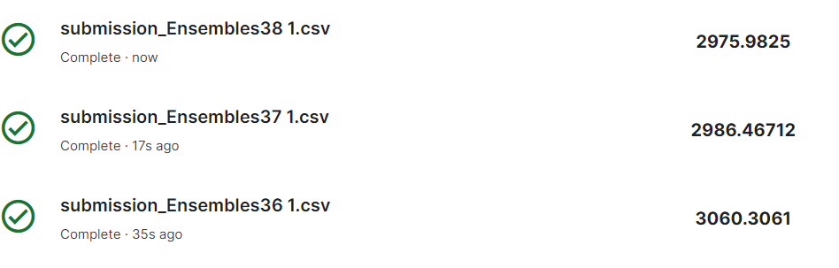